# WEEK 2 SECONDARY PROJECT

##Problem Definition

Kira Plastinina is a Russian brand that is sold through a defunct chain of retail stores in Russia, Ukraine, Kazakhstan, Belarus, China, Philippines, and Armenia. The brand’s Sales and Marketing team would like to understand their customer’s behavior from data that they have collected over the past year. More specifically, they would like to learn the characteristics of customer groups. Data Sourcing

## Check the Data

```r
data<-read.csv("http://bit.ly/EcommerceCustomersDataset")
head(df)
```

```
##
## 1 function (x, df1, df2, ncp, log = FALSE)
## 2 {
## 3     if (missing(ncp))
## 4         .Call(C_df, x, df1, df2, log)
## 5     else .Call(C_dnf, x, df1, df2, ncp, log)
## 6 }
```

```r
str(data)
```

```
## 'data.frame':    12330 obs. of  18 variables:
##  $ Administrative         : int  0 0 0 0 0 0 0 1 0 0 ...
##  $ Administrative_Duration: num  0 0 -1 0 0 0 -1 -1 0 0 ...
##  $ Informational          : int  0 0 0 0 0 0 0 0 0 0 ...
##  $ Informational_Duration : num  0 0 -1 0 0 0 -1 -1 0 0 ...
##  $ ProductRelated         : int  1 2 1 2 10 19 1 1 2 3 ...
##  $ ProductRelated_Duration: num  0 64 -1 2.67 627.5 ...
##  $ BounceRates            : num  0.2 0 0.2 0.05 0.02 ...
##  $ ExitRates              : num  0.2 0.1 0.2 0.14 0.05 ...
##  $ PageValues             : num  0 0 0 0 0 0 0 0 0 0 ...
##  $ SpecialDay             : num  0 0 0 0 0 0 0.4 0 0.8 0.4 ...
##  $ Month                  : chr  "Feb" "Feb" "Feb" "Feb" ...
##  $ OperatingSystems       : int  1 2 4 3 3 2 2 1 2 2 ...
##  $ Browser                : int  1 2 1 2 3 2 4 2 2 4 ...
##  $ Region                 : int  1 1 9 2 1 1 3 1 2 1 ...
##  $ TrafficType            : int  1 2 3 4 4 3 3 5 3 2 ...
##  $ VisitorType            : chr  "Returning_Visitor" "Returning_Visitor" "Returning_Visitor" "Returning_Visitor" ...
##  $ Weekend                : logi  FALSE FALSE FALSE FALSE TRUE FALSE ...
##  $ Revenue                : logi  FALSE FALSE FALSE FALSE FALSE FALSE ...
```

# Checking for Duplicates and Uniques values

```r
duplicated_row <- data[duplicated(data),]
```

```r
unique_values <- data[!duplicated(data), ]
```

```r
df_d= dim(duplicated_row)
df_d
```

```
## [1] 119  18
```

Checking and dropping the null values

```r
null_values = colSums(is.na(data))
```

```r
df <- data[!duplicated(data), ]
```

```r
df <- na.omit(data) # Method 1 - Remove NA
```

```r
null_values = colSums(is.na(df))

null_values
```

```
##          Administrative Administrative_Duration           Informational
##                       0                       0                       0
##  Informational_Duration          ProductRelated ProductRelated_Duration
##                       0                       0                       0
##             BounceRates               ExitRates              PageValues
##                       0                       0                       0
##              SpecialDay                   Month        OperatingSystems
##                       0                       0                       0
##                 Browser                  Region             TrafficType
##                       0                       0                       0
##             VisitorType                 Weekend                 Revenue
##                       0                       0                       0
```

```r
par(mfrow = c(2,2), mar = c(5,4,2,2))
```

# Checking for outliers

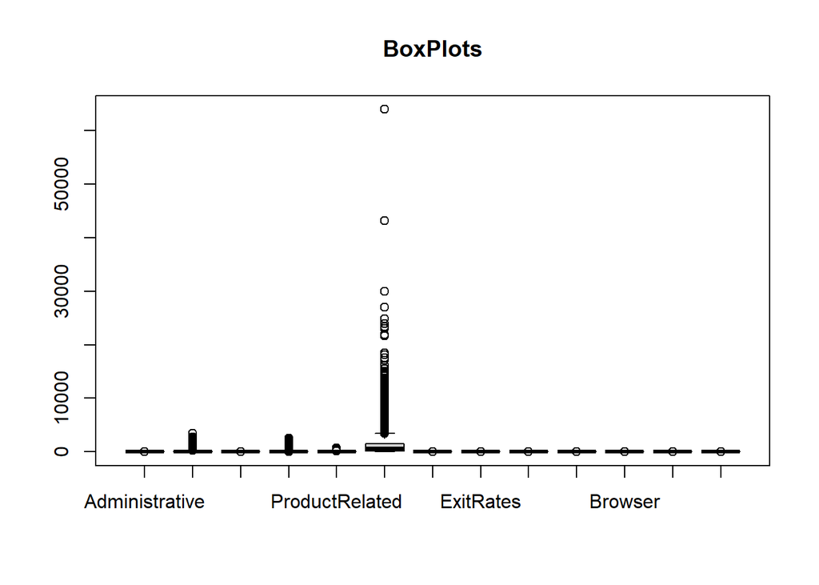

```r
df_num <- df[, !sapply(df, is.character)]
df_num <- subset(df_num,select = c(1,2,3,4,5,6,7,8,10,11,12,13,14))
boxplot(df_num, main='BoxPlots')
```

## Finding mean mode median

```r
str(df)
```

```
## 'data.frame':    12316 obs. of  18 variables:
##  $ Administrative         : int  0 0 0 0 0 0 0 1 0 0 ...
##  $ Administrative_Duration: num  0 0 -1 0 0 0 -1 -1 0 0 ...
##  $ Informational          : int  0 0 0 0 0 0 0 0 0 0 ...
##  $ Informational_Duration : num  0 0 -1 0 0 0 -1 -1 0 0 ...
##  $ ProductRelated         : int  1 2 1 2 10 19 1 1 2 3 ...
##  $ ProductRelated_Duration: num  0 64 -1 2.67 627.5 ...
##  $ BounceRates            : num  0.2 0 0.2 0.05 0.02 ...
##  $ ExitRates              : num  0.2 0.1 0.2 0.14 0.05 ...
##  $ PageValues             : num  0 0 0 0 0 0 0 0 0 0 ...
##  $ SpecialDay             : num  0 0 0 0 0 0 0.4 0 0.8 0.4 ...
##  $ Month                  : chr  "Feb" "Feb" "Feb" "Feb" ...
##  $ OperatingSystems       : int  1 2 4 3 3 2 2 1 2 2 ...
##  $ Browser                : int  1 2 1 2 3 2 4 2 2 4 ...
##  $ Region                 : int  1 1 9 2 1 1 3 1 2 1 ...
##  $ TrafficType            : int  1 2 3 4 4 3 3 5 3 2 ...
##  $ VisitorType            : chr  "Returning_Visitor" "Returning_Visitor" "Returning_Visitor" "Returning_Visitor" ...
##  $ Weekend                : logi  FALSE FALSE FALSE FALSE TRUE FALSE ...
##  $ Revenue                : logi  FALSE FALSE FALSE FALSE FALSE FALSE ...
##  - attr(*, "na.action")= 'omit' Named int [1:14] 1066 1133 1134 1135 1136 1137 1474 1475 1476 1477 ...
##   ..- attr(*, "names")= chr [1:14] "1066" "1133" "1134" "1135" ...
```

```r
library(dplyr)
df %>% summarise_if(is.numeric, median)
```

```
##   Administrative Administrative_Duration Informational Informational_Duration
## 1              1                       8             0                      0
##   ProductRelated ProductRelated_Duration BounceRates  ExitRates PageValues
## 1             18                599.7662 0.003119412 0.02512449          0
##   SpecialDay OperatingSystems Browser Region TrafficType
## 1          0                2       2      3           2
```

```r
library(dplyr)
df %>% summarise_if(is.numeric, mean)
```

```
##   Administrative Administrative_Duration Informational Informational_Duration
## 1       2.317798                80.90618     0.5039786               34.50639
##   ProductRelated ProductRelated_Duration BounceRates  ExitRates PageValues
## 1       31.76388                1196.037  0.02215246 0.04300254   5.895952
##   SpecialDay OperatingSystems  Browser   Region TrafficType
## 1 0.06149724         2.124147 2.357584 3.148019    4.070477
```

```r
library(psych)
desc <- describe(df)
desc
```

```
##                         vars     n    mean      sd median trimmed    mad min
## Administrative             1 12316    2.32    3.32   1.00    1.63   1.48   0
## Administrative_Duration    2 12316   80.91  176.86   8.00   42.19  11.86  -1
## Informational              3 12316    0.50    1.27   0.00    0.18   0.00   0
## Informational_Duration     4 12316   34.51  140.83   0.00    3.60   0.00  -1
## ProductRelated             5 12316   31.76   44.49  18.00   22.78  19.27   0
## ProductRelated_Duration    6 12316 1196.04 1914.37 599.77  821.41 743.05  -1
## BounceRates                7 12316    0.02    0.05   0.00    0.01   0.00   0
## ExitRates                  8 12316    0.04    0.05   0.03    0.03   0.02   0
## PageValues                 9 12316    5.90   18.58   0.00    1.30   0.00   0
## SpecialDay                10 12316    0.06    0.20   0.00    0.00   0.00   0
## Month*                    11 12316    6.16    2.37   7.00    6.35   1.48   1
## OperatingSystems          12 12316    2.12    0.91   2.00    2.06   0.00   1
## Browser                   13 12316    2.36    1.72   2.00    2.00   0.00   1
## Region                    14 12316    3.15    2.40   3.00    2.79   2.97   1
## TrafficType               15 12316    4.07    4.02   2.00    3.22   1.48   1
## VisitorType*              16 12316    2.72    0.69   3.00    2.90   0.00   1
## Weekend                   17 12316     NaN      NA     NA     NaN     NA Inf
## Revenue                   18 12316     NaN      NA     NA     NaN     NA Inf
##                              max    range  skew kurtosis    se
## Administrative             27.00    27.00  1.96     4.69  0.03
## Administrative_Duration  3398.75  3399.75  5.61    50.48  1.59
## Informational              24.00    24.00  4.03    26.89  0.01
## Informational_Duration   2549.38  2550.38  7.57    76.18  1.27
## ProductRelated            705.00   705.00  4.34    31.17  0.40
## ProductRelated_Duration 63973.52 63974.52  7.26   137.03 17.25
## BounceRates                 0.20     0.20  2.95     7.75  0.00
## ExitRates                   0.20     0.20  2.15     4.04  0.00
## PageValues                361.76   361.76  6.38    65.53  0.17
## SpecialDay                  1.00     1.00  3.30     9.89  0.00
## Month*                     10.00     9.00 -0.83    -0.37  0.02
## OperatingSystems            8.00     7.00  2.07    10.45  0.01
## Browser                    13.00    12.00  3.24    12.73  0.02
## Region                      9.00     8.00  0.98    -0.15  0.02
## TrafficType                20.00    19.00  1.96     3.48  0.04
## VisitorType*                3.00     2.00 -2.06     2.28  0.01
## Weekend                     -Inf     -Inf    NA       NA    NA
## Revenue                     -Inf     -Inf    NA       NA    NA
```

## standard deviation and variance

```r
my.sd <- unlist(lapply(df, sd)); my.sd
```

```
##          Administrative Administrative_Duration           Informational
##            3.322754e+00            1.768604e+02            1.270701e+00
##  Informational_Duration          ProductRelated ProductRelated_Duration
##            1.408255e+02            4.449034e+01            1.914373e+03
##             BounceRates               ExitRates              PageValues
##            4.842713e-02            4.852730e-02            1.857793e+01
##              SpecialDay                   Month        OperatingSystems
##            1.990195e-01                      NA            9.115659e-01
##                 Browser                  Region             TrafficType
##            1.718028e+00            2.402211e+00            4.024598e+00
##             VisitorType                 Weekend                 Revenue
##                      NA            4.225218e-01            3.618435e-01
```

```r
my.var <- unlist(lapply(df, var)); my.var
```

```
##          Administrative Administrative_Duration           Informational
##            1.104069e+01            3.127961e+04            1.614682e+00
##  Informational_Duration          ProductRelated ProductRelated_Duration
##            1.983182e+04            1.979390e+03            3.664822e+06
##             BounceRates               ExitRates              PageValues
##            2.345187e-03            2.354899e-03            3.451393e+02
##              SpecialDay                   Month        OperatingSystems
##            3.960877e-02                      NA            8.309524e-01
##                 Browser                  Region             TrafficType
##            2.951620e+00            5.770618e+00            1.619739e+01
##             VisitorType                 Weekend                 Revenue
##                      NA            1.785247e-01            1.309307e-01
```

```r
summary(df)
```

```
##  Administrative   Administrative_Duration Informational
##  Min.   : 0.000   Min.   :  -1.00         Min.   : 0.000
##  1st Qu.: 0.000   1st Qu.:   0.00         1st Qu.: 0.000
##  Median : 1.000   Median :   8.00         Median : 0.000
##  Mean   : 2.318   Mean   :  80.91         Mean   : 0.504
##  3rd Qu.: 4.000   3rd Qu.:  93.50         3rd Qu.: 0.000
##  Max.   :27.000   Max.   :3398.75         Max.   :24.000
##  Informational_Duration ProductRelated   ProductRelated_Duration
##  Min.   :  -1.00        Min.   :  0.00   Min.   :   -1.0
##  1st Qu.:   0.00        1st Qu.:  7.00   1st Qu.:  185.0
##  Median :   0.00        Median : 18.00   Median :  599.8
##  Mean   :  34.51        Mean   : 31.76   Mean   : 1196.0
##  3rd Qu.:   0.00        3rd Qu.: 38.00   3rd Qu.: 1466.5
##  Max.   :2549.38        Max.   :705.00   Max.   :63973.5
##   BounceRates         ExitRates         PageValues        SpecialDay
##  Min.   :0.000000   Min.   :0.00000   Min.   :  0.000   Min.   :0.0000
##  1st Qu.:0.000000   1st Qu.:0.01429   1st Qu.:  0.000   1st Qu.:0.0000
##  Median :0.003119   Median :0.02512   Median :  0.000   Median :0.0000
##  Mean   :0.022152   Mean   :0.04300   Mean   :  5.896   Mean   :0.0615
##  3rd Qu.:0.016684   3rd Qu.:0.05000   3rd Qu.:  0.000   3rd Qu.:0.0000
##  Max.   :0.200000   Max.   :0.20000   Max.   :361.764   Max.   :1.0000
##     Month           OperatingSystems    Browser           Region
##  Length:12316       Min.   :1.000    Min.   : 1.000   Min.   :1.000
##  Class :character   1st Qu.:2.000    1st Qu.: 2.000   1st Qu.:1.000
##  Mode  :character   Median :2.000    Median : 2.000   Median :3.000
##                     Mean   :2.124    Mean   : 2.358   Mean   :3.148
##                     3rd Qu.:3.000    3rd Qu.: 2.000   3rd Qu.:4.000
##                     Max.   :8.000    Max.   :13.000   Max.   :9.000
##   TrafficType    VisitorType         Weekend         Revenue
##  Min.   : 1.00   Length:12316       Mode :logical   Mode :logical
##  1st Qu.: 2.00   Class :character   FALSE:9451      FALSE:10408
##  Median : 2.00   Mode  :character   TRUE :2865      TRUE :1908
##  Mean   : 4.07
##  3rd Qu.: 4.00
##  Max.   :20.00
```

# Barplots

```r
Month<- (df$Month)
Month_frequency <- table(Month)
Month_frequency
```

```
## Month
##  Aug  Dec  Feb  Jul June  Mar  May  Nov  Oct  Sep
##  433 1727  184  432  288 1894 3363 2998  549  448
```

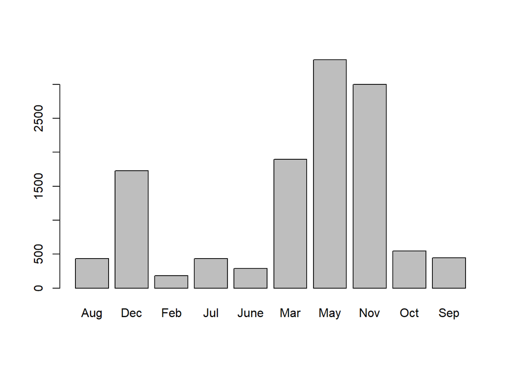

```r
Month_barplot <- barplot(Month_frequency)
```

```r
Month_barplot
```

```
##       [,1]
##  [1,]  0.7
##  [2,]  1.9
##  [3,]  3.1
##  [4,]  4.3
##  [5,]  5.5
##  [6,]  6.7
##  [7,]  7.9
##  [8,]  9.1
##  [9,] 10.3
## [10,] 11.5
```

The most common months for visiting any particular pages was March ,May and November

# Administrative

```r
Administrative<- (df$Administrative)
Administrative_frequency <- table(Administrative)
Administrative_frequency
```

```
## Administrative
##    0    1    2    3    4    5    6    7    8    9   10   11   12   13   14   15
## 5754 1354 1114  915  765  575  432  338  287  225  153  105   86   56   44   38
##   16   17   18   19   20   21   22   23   24   26   27
##   24   16   12    6    2    2    4    3    4    1    1
```

VisitorType

```r
 VisitorType <- (df$ VisitorType)
 VisitorType_frequency <- table(VisitorType)
 VisitorType_frequency
```

```
## VisitorType
##       New_Visitor             Other Returning_Visitor
##              1694                85             10537
```

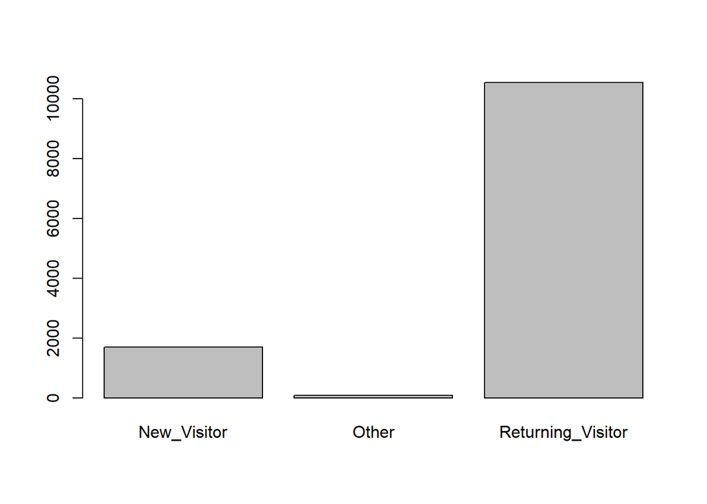

```r
VisitorType_barplot <- barplot(VisitorType_frequency)
```

```r
VisitorType_barplot
```

```
##      [,1]
## [1,]  0.7
## [2,]  1.9
## [3,]  3.1
```

Returning visitors were the most common followed by the New visitors

```r
Weekend <- (df$Weekend)
Weekend_frequency <- table(Weekend)
Weekend_frequency
```

```
## Weekend
## FALSE  TRUE
##  9451  2865
```

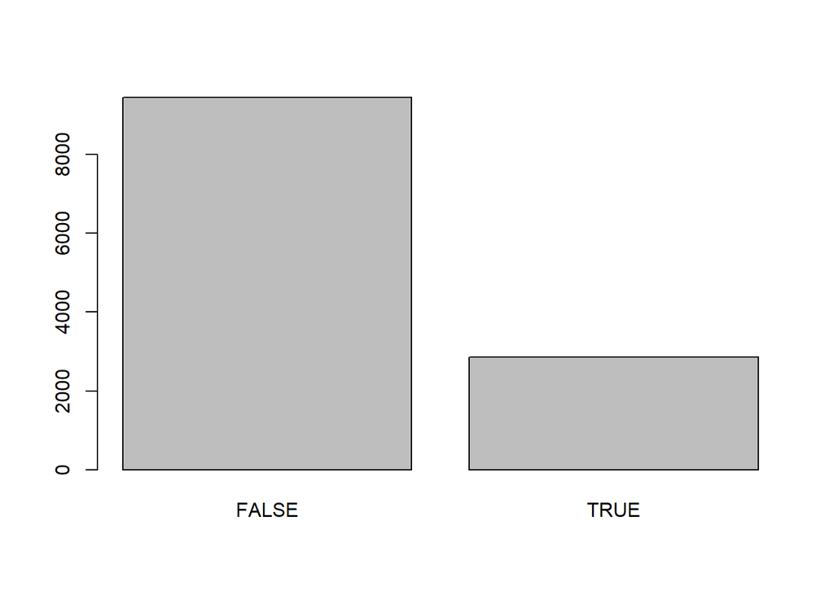

```r
Weekend_barplot <- barplot(Weekend_frequency)
```

```r
Weekend_barplot
```

```
##      [,1]
## [1,]  0.7
## [2,]  1.9
```

```r
Region<- (df$Region)
Region_frequency <- table(Region)
Region_frequency
```

```
## Region
##    1    2    3    4    5    6    7    8    9
## 4774 1134 2402 1179  317  804  761  434  511
```

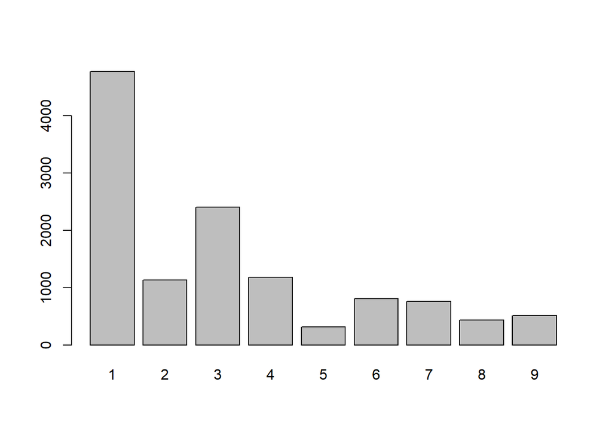

```r
Region_barplot <- barplot(Region_frequency)
```

```r
Region_barplot
```

```
##       [,1]
##  [1,]  0.7
##  [2,]  1.9
##  [3,]  3.1
##  [4,]  4.3
##  [5,]  5.5
##  [6,]  6.7
##  [7,]  7.9
##  [8,]  9.1
##  [9,] 10.3
```

Region 1 had the most number of counts followed by region 3

```r
Revenue <- (df$Revenue)
Revenue_frequency <- table(Revenue)
Revenue_frequency
```

```
## Revenue
## FALSE  TRUE
## 10408  1908
```

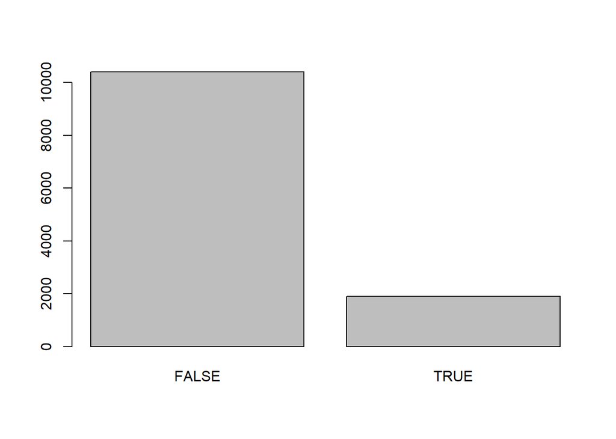

```r
Revenue_barplot <- barplot(Revenue_frequency)
```

```r
Revenue_barplot
```

```
##      [,1]
## [1,]  0.7
## [2,]  1.9
```

```r
TrafficType <- (df$TrafficType)
TrafficType_frequency <- table(TrafficType)
TrafficType_frequency
```

```
## TrafficType
##    1    2    3    4    5    6    7    8    9   10   11   12   13   14   15   16
## 2444 3909 2051 1069  260  444   40  343   42  450  247    1  737   13   37    3
##   17   18   19   20
##    1   10   17  198
```

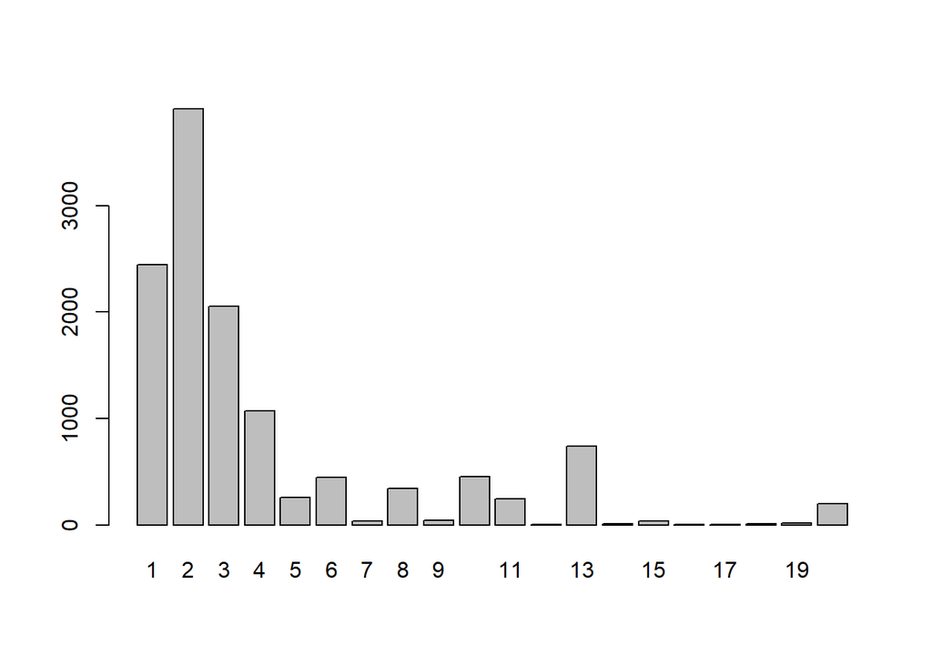

```r
TrafficType_barplot <- barplot(TrafficType_frequency)
```

```r
TrafficType_barplot
```

```
##       [,1]
##  [1,]  0.7
##  [2,]  1.9
##  [3,]  3.1
##  [4,]  4.3
##  [5,]  5.5
##  [6,]  6.7
##  [7,]  7.9
##  [8,]  9.1
##  [9,] 10.3
## [10,] 11.5
## [11,] 12.7
## [12,] 13.9
## [13,] 15.1
## [14,] 16.3
## [15,] 17.5
## [16,] 18.7
## [17,] 19.9
## [18,] 21.1
## [19,] 22.3
## [20,] 23.5
```

1,2 and 3 were the most popular type of Traffic